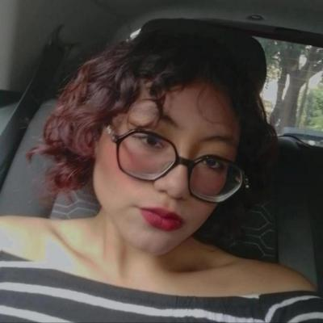

# Zyanya Velazquez

## Bio

Zyanya Valentina Velazquez Aldrete is an undergraduate researcher in Genomic Sciences at the National Autonomous University of Mexico (UNAM). Her work bridges molecular microbiology, evolutionary genomics, and systems biology through the integration of experimental and computational approaches.

She is currently involved in three research lines: antimicrobial discovery from environmental bacterial isolates, mathematical modeling of pulmonary fibrosis dynamics, and comparative genomics of aging and longevity in reptiles. Her research interests include phylogenetic comparative methods, evolutionary analysis, genome-wide data integration, and the development of minimal mathematical models to understand biological regulation and disease-associated transitions.

She works primarily in R, Python, and Linux-based environments, focusing on reproducible computational workflows and quantitative biological analysis.

## Education

**National Autonomous University of Mexico (UNAM)** | Morelos, Mexico  
B.Sc. in Genomic Sciences | 2024 – Present

**National Preparatory School (UNAM)** | Mexico City, Mexico  
Histopathology Technician | 2022 – 2023

## Research Experience

**Evolutionary and Functional Genomics Lab – Institute of Ecology, UNAM**  
Undergraduate Researcher | Nov 2025 – Present

- Genome-wide comparative analyses to identify molecular signatures associated with aging and longevity in reptiles.
- Ortholog identification, sequence alignment, substitution rate estimation, and detection of selective pressures.
- Processing and quality control of genome and transcriptome datasets.
- Implementation of phylogenetic and evolutionary analyses in R and Python.

**Evolutionary Systems Biology Lab – LIIGH, UNAM**  
Undergraduate Researcher | Jun 2025 – Present

- Development of a minimal mathematical model describing inflammation–fibroblast dynamics in pulmonary fibrosis.
- Translation of biological regulatory mechanisms into systems of differential equations.
- Computational simulations, stability analysis, and parameter exploration in Python/MATLAB.

**Molecular Microbiology – Biotechnology Institute (IBt), UNAM**  
Undergraduate Researcher | Jan 2025 – Present

- Isolation and screening of bacteria producing antimicrobial compounds from mangrove soils.
- Design of inhibition assays against clinically relevant pathogens.
- Extraction of secondary metabolites and evaluation of antimicrobial activity.
- DNA extraction and sequencing for taxonomic identification.

## Skills

**Programming & Computational Tools**  
R · Python · Linux · Bash · Git · RStudio · Jupyter Notebook

**Bioinformatics & Data Analysis**  
Comparative genomics · Sequence analysis · Evolutionary analysis · Statistical modeling · Phylogenetic methods

**Languages**  
Spanish (Native) · English (B2)